# index

## Introducción

### Marco del problema

Entre los costos que más desastibilizan económicamente a las personas, se encuentra el pago por procedimientos médicos. Estos precios pueden variar en gran medida dependiendo de características del paciente, como detallaremos más adelante.

En ese sentido, resulta de gran valor predecir adecuadamente el costo que un seguro médico cubrirá, respecto a un procedimiento médico. Para un paciente, aquella predicción puede servir para que planifique qué tanto sería desestabilizado económicamente debido a algún tipo de procedimiento particular. Por otro lado, también para las aseguradoras resulta útil aquellas predicciones, ya que pueden anticipar qué tanto dinero estarían perdiendo por el monto a cubrir de la operación; además, con ese conocimiento pueden monitorear mejor qué pedidos de cobertura resultan anómalos, potencialmente fraudulentos.

### Plan de modelamiento

Anteriormente, hemos planteado como variable por predecir a la cantidad monetaria que la aseguradora de un paciente cubrirá debido a un procedimiento médico. Note que aquel monto está muy relacionado al precio que paga el paciente luego que el seguro descuenta parte del costo del procedimiento médico … ese monto, que denominaremos `charges`, se intentará predecir.

Asimismo, vale recalcar la influencia de los gastos del hospital debido al procedimiento médico, variable que denotaremos `Hospital_expenditure`, sobre `charges`.

Para el modelamiento, se considerará además las siguientes características del paciente:

- Sexo (`age`)
- Si fuma o no (`smoker`)
- Región de la que provee (`region`)
- Edad (`age`)
- Índice de masa corporal (`bmi`)
- Cantidad de hijos e hijas (`children`)
- Costo médico que pagaría en caso no se aplicase seguro médico (`Claim_Amount`)
- Número de procedimientos pasados (`past_consultations`)
- Número de pasos que realizó en cierto día (`num_of_steps`)
- Número de veces que ha sido hospitalizado (`Number_of_past_hospitalizations`)
- Salario anual (`Anual_Salary`)

## Metodología

### Datos/Observaciones

Las observaciones que consideraremos para este proyecto fueron descargadas de este sitio [web](https://www.kaggle.com/datasets/shubhamsingh57/ml-model-practice-linear-regression/data).

Estos datos son de distintos pacientes que recibieron algún tipo de tratamiento médico, de los cuales se tienen variables recopiladas, como edad, sexo, si fuma o no, etc. Así, descartamos que los datos consistan de una serie de tiempo.

No obstante, aquella página web no provee información más específica sobre el origen de los datos. Por ejemplo, si han sido recopilados en un único hospital, o en diversos hospitales, pero de qué país, etc.

Aún así, en esta investigación, no solo se considera la predicción de la variable mencionada, sino también cómo es que influyen las variables que emplearemos como regresores, en la predicción final. Por ejemplo, si su relación es directa o inversamente proporcional.

A continuación justificamos el posible uso de los caracteres presentes en los datos, como covariables:

- **Sexo**: Debido al riesgo y costos distintos entre hombres y mujeres, para ciertos tipos de operaciones; por ejemplo, parto.
- **Si fuma o no**: Pues fumar aumenta la probabilidad de desarrollar complicaciones médicas
- **Región de la que provee**: Ya que el costo de un procedimiento médico puede variar mucho por región, así que también varía cuánto cubriría una aseguradora.
- **Edad**: Puesto que pacientes mayores suelen requerir más cuidados.
- **Índice de masa corporal**: En base a que un IMC elevado está asociado a mayores riesgos durante cirugías.
- **Cantidad de hijos e hijas**: Esto puede influir en el tipo de cobertura familiar (de seguro) que tiene el paciente.
- **Costo médico que pagaría en caso no se aplicase seguro médico**: Importante incluirlo, pues incluso se espera que presente una fuerte correlación positiva con la variable por predecir.
- **Número de procedimientos pasados**: Puede resultar útil en base a que pacientes con muchos procedimientos suelen tener enfermedades crónicas, por lo que se esperaría una mayor cobertura.
- **Número de pasos que realizó en cierto día**: Esta variable tampoco se explica en la fuente, pero la podemos considerar como una medida de la condición física de una persona, qué tan activa es.
- **Número de veces que ha sido hospitalizado**: Pues más hospitalizaciones implican mayor riesgo en la operación, aumentando posiblemente así los costos que cubre la aseguradora.
- **Salario anual**: Como indicador de nivel socioeconómico, se espera que pacientes con ingresos altos cuenten con aseguradoras que cubren mayor parte el costo por intervención médica.

### Itinerario metodológico de la modelización

A continuación, describrimos los pasos a seguir para la construcción de diferentes modelos de predicción:

1. Descarte de observaciones que presenten algún valor faltante para cualquier variable.
2. Gráficos de dispersión para pares de variables
3. Debido al máximo establecido en este proyecto, respecto al número de covariables, calculamos las correlaciones múltiples
4. Filtro de observaciones al azar, debido a máximo establecido en este proyecto.
5. Limpieza de datos
6. Construcción del modelo OLS, empleando todas las covariables
7. Gráficos de valores observados y residuos contra valores estimados. Interpretar R^2
8. Emplear el test de Levine y Shapiro para averiguar la homocedasticidad y la normalidad.
9. En caso positivo, evaluar por medio de ANOVA si el modelo tiene sentido. En caso positivo, determinar qué variables explicativas tienen sentido.
10. Si se encuentran puntos aberrantes, recorrer el modelo sin aquellos y repetir los pasos mencionados.
11. Emplear selección por delante, para atrás y stepwise.
12. Ejecutar los tests de tipo ANOVA
13. En caso el test ANOVA relevante resulte positivo, incluir los tests post-hoc.

## Presentación y análisis de resultados

### Carga de datos

A continuación, mostramos los datos descargados del sitio web mencionado en la sección previa.

```r
library(dplyr)
library(tidyr)
library(ggplot2)
library(reshape2)
library(nlme)
library(glmnet)
```

```r
datos <- readr::read_csv("./new_insurance_data.csv")
dplyr::glimpse(datos)
```

```
Rows: 1,338
Columns: 13
$ age                             <dbl> 18, 18, 18, 18, 18, 18, 18, 18, 18, 18~
$ sex                             <chr> "male", "male", "male", "male", "male"~
$ bmi                             <dbl> 23.21, 30.14, 33.33, 33.66, 34.10, 34.~
$ children                        <dbl> 0, 0, 0, 0, 0, 0, 0, 0, 0, 0, 0, 0, 0,~
$ smoker                          <chr> "no", "no", "no", "no", "no", "no", "n~
$ Claim_Amount                    <dbl> 29087.543, 39053.674, 39023.628, 28185~
$ past_consultations              <dbl> 17, 7, 19, 11, 16, 20, 13, 12, 17, 19,~
$ num_of_steps                    <dbl> 715428, 699157, 702341, 700250, 711584~
$ Hospital_expenditure            <dbl> 4720921.0, 4329831.7, 6884860.8, 42747~
$ Number_of_past_hospitalizations <dbl> 0, 0, 0, 0, 0, 0, 0, 0, 0, 0, 0, 0, NA~
$ Anual_Salary                    <dbl> 55784970, 13700885, 73523107, 75819680~
$ region                          <chr> "southeast", "southeast", "southeast",~
$ charges                         <dbl> 1121.874, 1131.507, 1135.941, 1136.399~
```

Descartamos las observaciones con alguna variable faltante.

```r
# Cantidad de observaciones
nrow(datos)
```

```
[1] 1338
```

```r
# Cantidad de observaciones con alguna variable faltante
sum(!complete.cases(datos))
```

```
[1] 51
```

```r
datos <- tidyr::drop_na(datos)
```

### Filtro de variables

#### Graficos de dispersión

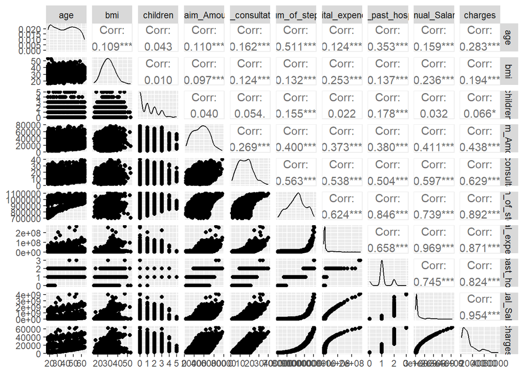

```r
covariables_numericas <- c(
  "age",
  "bmi",
  "children",
  "Claim_Amount",
  "past_consultations",
  "num_of_steps",
  "Hospital_expenditure",
  "Number_of_past_hospitalizations",
  "Anual_Salary"
)
columnas_numericas <- c(covariables_numericas, "charges")

GGally::ggpairs(datos[, columnas_numericas])
```

Nótese que la variable por predecir, `charges`, parece presentar una relación lineal con la covariable `Annual_Salary`. Asimismo, parece haber indicios de que resulta posible transformar las variables `num_of_steps` y `Hospital_expenditure` por funciones logaritmo y exponcial, respectivamente, con fin que se tenga una fuerte relación lineal entre el predictor creado y la variable por predecir.

#### Correlaciones parciales entre covariables

```r
d.cor <- cor(datos[, covariables_numericas])
d.inv <- solve(d.cor)

d.corm <- sqrt(1-1/diag(d.inv))
pd <- length(d.corm)


d.part <- d.inv
for (i in 1:pd) {
  for (j in 1:(i-1)) {
    d.part[i,j] <- -d.inv[i,j]/sqrt(d.inv[i,i]*d.inv[j,j])
  }
  d.part[i,i] <- d.corm[i]
  d.part[1:(i-1),i] <- d.part[i,1:(i-1)]
}
d.part
```

```
                                        age          bmi     children
age                              0.66869810  0.125138033 -0.127797419
bmi                              0.12513803  0.283723310  0.027431191
children                        -0.12779742  0.027431191  0.285534954
Claim_Amount                    -0.04743308  0.019145260 -0.007971203
past_consultations              -0.03242764  0.002848758  0.011798696
num_of_steps                     0.58296028 -0.073153318  0.147382251
Hospital_expenditure             0.30690425  0.031794571  0.128345835
Number_of_past_hospitalizations -0.02225606 -0.018175497  0.140432728
Anual_Salary                    -0.38460223  0.034625132 -0.173171362
                                Claim_Amount past_consultations num_of_steps
age                             -0.047433079       -0.032427643   0.58296028
bmi                              0.019145260        0.002848758  -0.07315332
children                        -0.007971203        0.011798696   0.14738225
Claim_Amount                     0.439018730       -0.005991357   0.09098912
past_consultations              -0.005991357        0.630532156   0.13217102
num_of_steps                     0.090989121        0.132171021   0.93080551
Hospital_expenditure            -0.016667332       -0.087954734  -0.49727359
Number_of_past_hospitalizations  0.023096940       -0.056723682   0.45898240
Anual_Salary                     0.052074797        0.162444557   0.56078648
                                Hospital_expenditure
age                                       0.30690425
bmi                                       0.03179457
children                                  0.12834583
Claim_Amount                             -0.01666733
past_consultations                       -0.08795473
num_of_steps                             -0.49727359
Hospital_expenditure                      0.98147153
Number_of_past_hospitalizations          -0.04913622
Anual_Salary                              0.95773182
                                Number_of_past_hospitalizations Anual_Salary
age                                                 -0.02225606  -0.38460223
bmi                                                 -0.01817550   0.03462513
children                                             0.14043273  -0.17317136
Claim_Amount                                         0.02309694   0.05207480
past_consultations                                  -0.05672368   0.16244456
num_of_steps                                         0.45898240   0.56078648
Hospital_expenditure                                -0.04913622   0.95773182
Number_of_past_hospitalizations                      0.86849267   0.13449231
Anual_Salary                                         0.13449231   0.98774064
```

```r
vals_diag <- diag(d.part)
max_col_indices <- apply(d.part, 1, which.max)
idx_ordenados <- order(vals_diag, decreasing = TRUE)
ordenados_vals_diag <- vals_diag[idx_ordenados]
ordenados_max_cols <- max_col_indices[idx_ordenados]

data.frame(correlacion_parcial = ordenados_vals_diag)
```

```
                                correlacion_parcial
Anual_Salary                              0.9877406
Hospital_expenditure                      0.9814715
num_of_steps                              0.9308055
Number_of_past_hospitalizations           0.8684927
age                                       0.6686981
past_consultations                        0.6305322
Claim_Amount                              0.4390187
children                                  0.2855350
bmi                                       0.2837233
```

Note que cuatro covariables presentan correlación parcial mayor a 0.8, en orden descendente `Anual_Salary`, `Hospital_expenditure`, `num_of_steps` y `Number_of_past_hospitalizations`. Aquellas variables son muy explicadas por las demás (posible multicolinearidad).

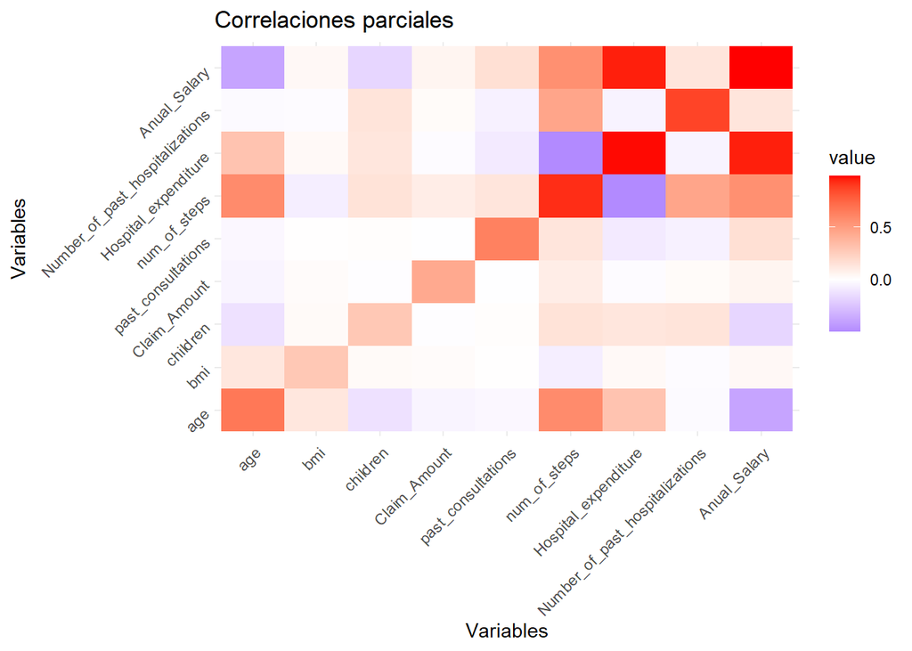

Inspeccionemos ahora, de manera particular, las correlaciones entre covariables

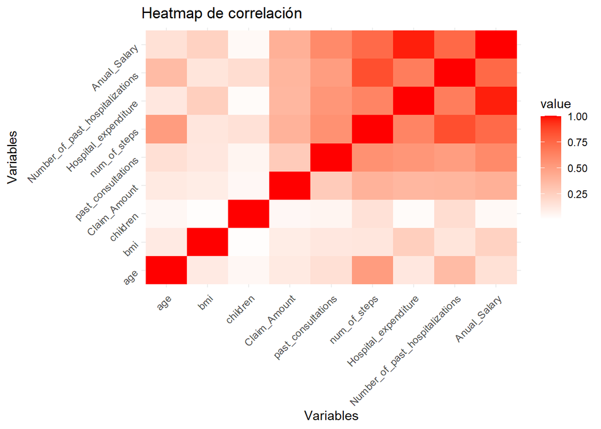

Observamos una alta correlación entre `Anual_Salary` y `Hospital_expenditure`, con un valor de $0.9692177$ Asimismo, como la variable de salario anual es más sencilla de recopilar (por ejemplo, en una encuesta) que la de gasto de hospital, descartamos la variable cuantitativa `Hospital_expenditure`.

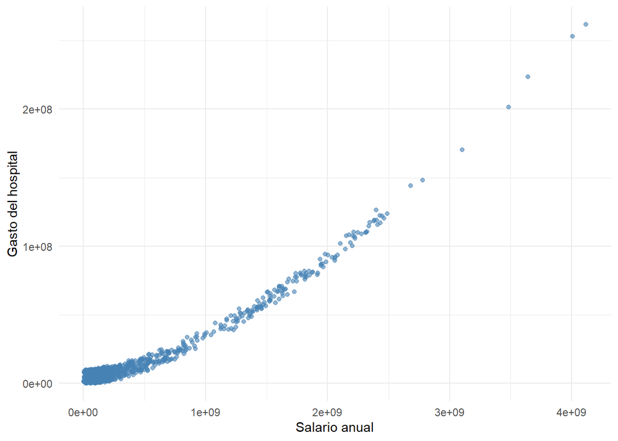

```r
datos |>
  ggplot(aes(x = Anual_Salary, y = Hospital_expenditure)) +
  geom_point(color = "steelblue", alpha = 0.6) +
  labs(x = "Salario anual", y = "Gasto del hospital") +
  theme_minimal()
```

#### Variable cuantitativa `num_of_steps`

Inicialmente se consideró descartar la variable referente al número de pasos que realizó el paciente en cierto día. Esto pues, a primera vista, no se esperaría que tal información resulte relevante para el costo final por el procedimiento médico.

Graficamos tal posible regreso contra la variable respuesta:

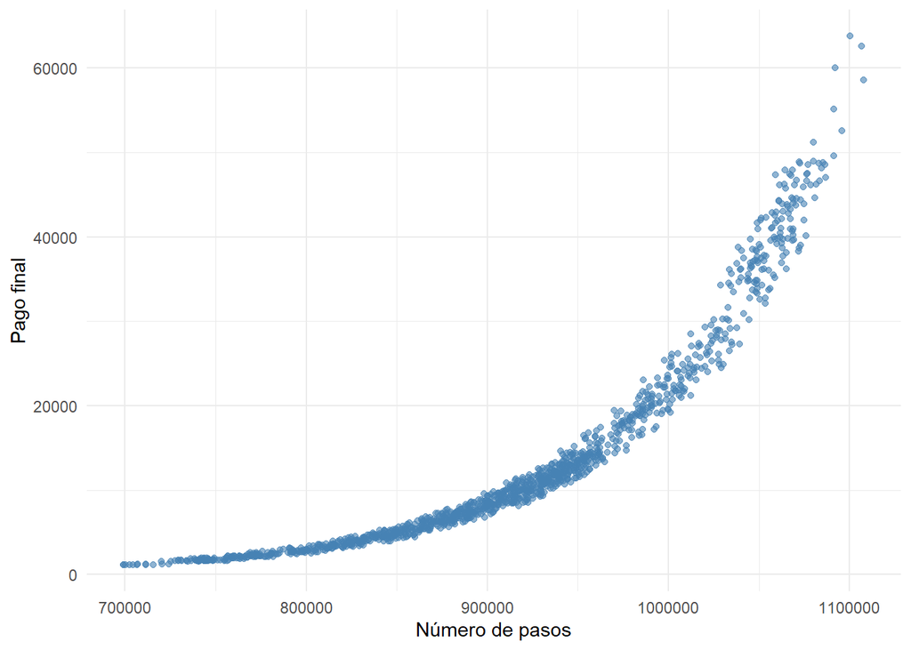

```r
datos |>
  ggplot(aes(x = num_of_steps, y = charges)) +
  geom_point(color = "steelblue", alpha = 0.6) +
  labs(x = "Número de pasos", y = "Pago final") +
  theme_minimal()
```

En base a que la relación parece asemejarse a una exponencial, graficamos la variable `num_of_steps` contra el logaritmo de la variable respuesta:

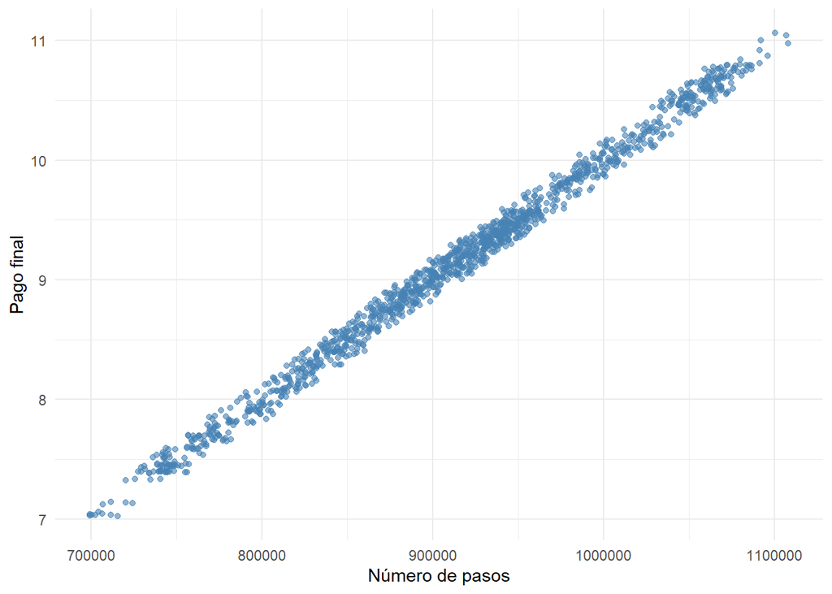

```r
datos |>
  dplyr::mutate(scaled_rsp = log(charges)) |>
  ggplot(aes(x = num_of_steps, y = scaled_rsp)) +
  geom_point(color = "steelblue", alpha = 0.6) +
  labs(x = "Número de pasos", y = "Pago final") +
  theme_minimal()
```

En base a que aquella relación parece ser *aproximadamente* lineal, optamos por no descartar la variable cuantitativa `num_of_steps`.

#### Variable cuantitativa `age`

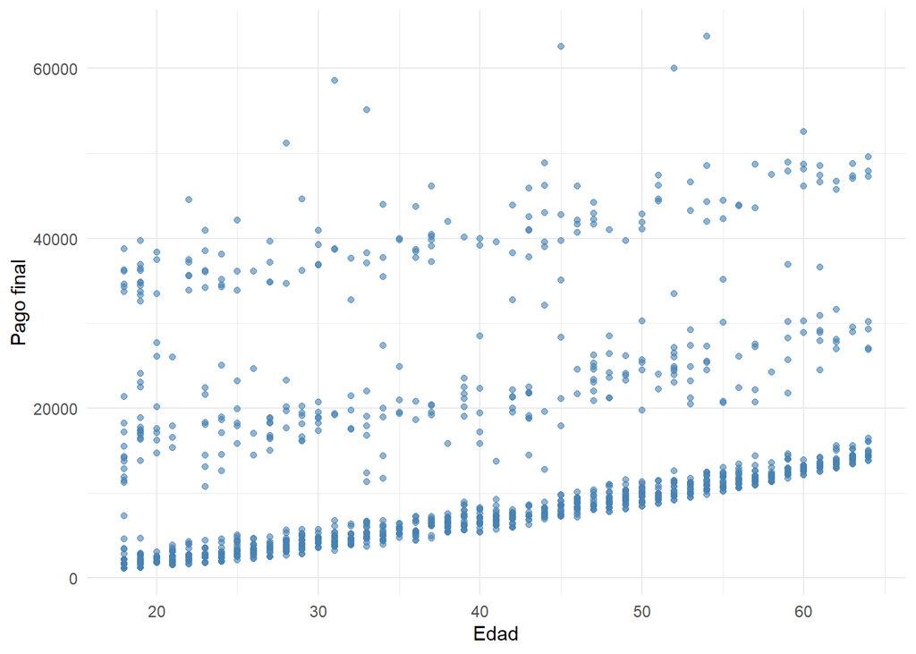

```r
datos |>
  ggplot(aes(x = age, y = charges)) +
  geom_point(color = "steelblue", alpha = 0.6) +
  labs(x = "Edad", y = "Pago final") +
  theme_minimal()
```

#### Variable cuantitativa `bmi`

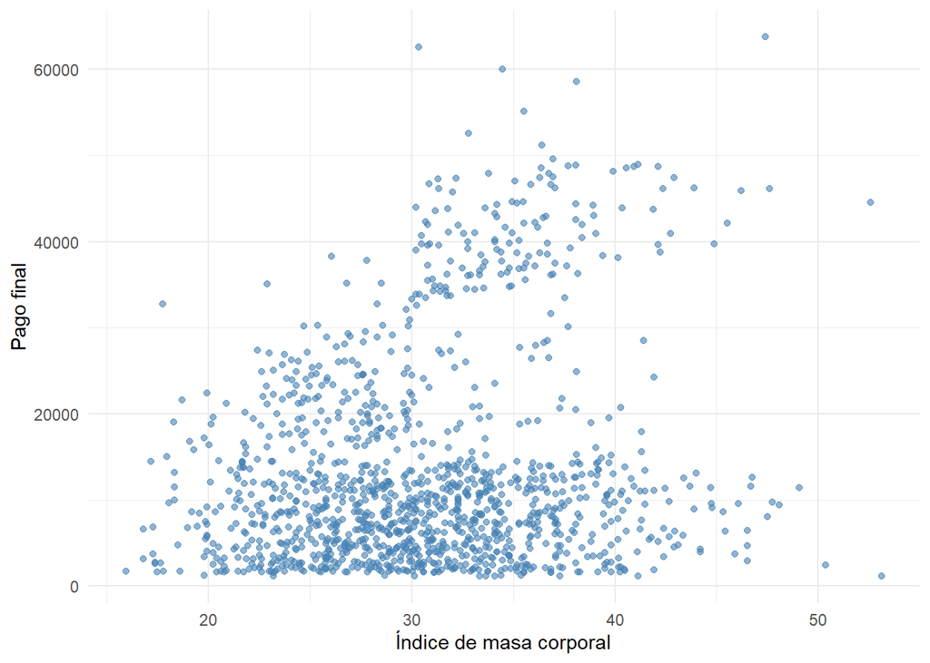

```r
datos |>
  ggplot(aes(x = bmi, y = charges)) +
  geom_point(color = "steelblue", alpha = 0.6) +
  labs(x = "Índice de masa corporal", y = "Pago final") +
  theme_minimal()
```

#### Variable cuantitativa `children`

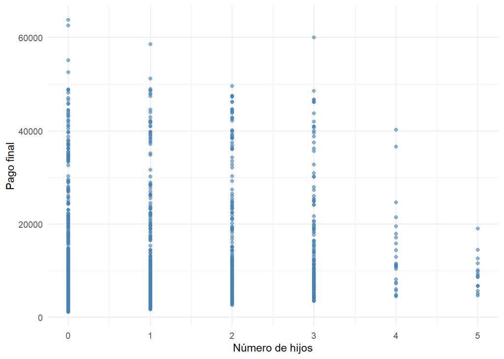

```r
datos |>
  ggplot(aes(x = children, y = charges)) +
  geom_point(color = "steelblue", alpha = 0.6) +
  labs(x = "Número de hijos", y = "Pago final") +
  theme_minimal()
```

#### Variable cuantitativa `past_consultations`

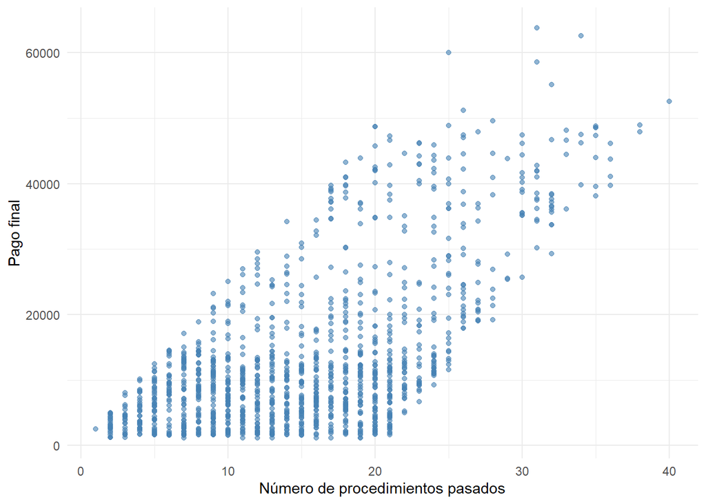

```r
datos |>
  ggplot(aes(x = past_consultations, y = charges)) +
  geom_point(color = "steelblue", alpha = 0.6) +
  labs(x = "Número de procedimientos pasados", y = "Pago final") +
  theme_minimal()
```

Descartamos la variable cuantitativa `children`, pues, en base a este simple análisis inicial, no parece indicar algún de tipo de relación lineal con la variable por predecir. Es más, su gráfico de dispersión parece sugerir que consideremos a la variable `children` como cualitativa.

#### Variables categóricas

Para el filtro de variables categóricas, descartaremos aquella para la cual las distribuciones de la variable respuesta, respecto a los valores de aquella variable categórica sean relativamente similares.

#### Variable cualitativa `region`

Inspeccionamos la distribución de la variable respuesta, respecto a los valores de la variable categórica `region`.

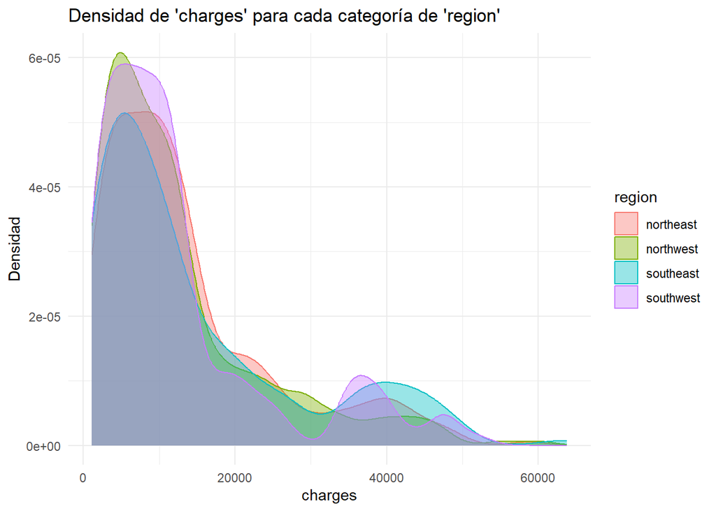

```r
datos |>
  ggplot(aes(x = charges, color = region, fill = region)) +
    geom_density(alpha = 0.4) +
    labs(
      title = "Densidad de 'charges' para cada categoría de 'region'",
      x = "charges",
      y = "Densidad"
    ) +
    theme_minimal()
```

En base a que aquellas funciones densidad no presentan una difencia resaltante, descartaremos la variable `region`. De esa manera, las variables cualitativas que emplearemos para esta investigación son solo `sex` y `smoker`.

#### Variables finales

- Variables cualitativas:
  - `sex`
  - `smoker`
- Variables cuantitativas:
  - `age`
  - `bmi`
  - `Claim_Amount`
  - `past_consultations`
  - `num_of_steps`
  - `Number_of_past_hospitalizations`
  - `Anual_Salary`
  - `charges` (**variable respuesta**)

Para limitarnos a 500 filas, según la restricción de este proyecto, realizaremos un muestreo:

```r
obs <- datos |>
  dplyr::select(
    sex,
    smoker,
    age,
    bmi,
    Claim_Amount,
    past_consultations,
    num_of_steps,
    Number_of_past_hospitalizations,
    Anual_Salary,
    charges
  )

set.seed(1234)
obs <- dplyr::sample_n(obs, 500)

openxlsx::write.xlsx(obs, './datos.xlsx')
```

### Modelamiento

```r
dplyr::glimpse(obs)
```

```
Rows: 500
Columns: 10
$ sex                             <chr> "male", "female", "male", "female", "m~
$ smoker                          <chr> "no", "no", "yes", "no", "no", "no", "~
$ age                             <dbl> 28, 40, 33, 48, 63, 48, 59, 38, 63, 22~
$ bmi                             <dbl> 33.820, 41.420, 27.100, 28.880, 31.445~
$ Claim_Amount                    <dbl> 24107.866, 27534.303, 39952.923, 45755~
$ past_consultations              <dbl> 18, 15, 27, 24, 14, 18, 18, 12, 11, 8,~
$ num_of_steps                    <dbl> 983349, 1031312, 996320, 912509, 95335~
$ Number_of_past_hospitalizations <dbl> 1, 2, 1, 1, 1, 1, 1, 1, 1, 0, 2, 1, 1,~
$ Anual_Salary                    <dbl> 481649496, 869010594, 453727467, 17846~
$ charges                         <dbl> 19673.336, 28476.735, 19040.876, 9249.~
```

Comencemos definiendo algunas funciones auxliares en el análisis y modelamiento.

```r
sum.lm <- function(lmod) {
  summ <- summary(lmod)
  ci <- confint(lmod)
  summ$coefficients <- cbind(
    summ$coefficients[,1],
    ci,summ$coefficients[,2:4]
  )
  return(summ)
}

extraer_estadistica_f <- function(modelo) {
  return(summary(modelo)$fstatistic[1])
}

obtener_p_valor_de_estadistica_f <- function(modelo) {
  s <- summary(modelo)

  fval <- s$fstatistic["value"]
  df1 <- s$fstatistic["numdf"]
  df2 <- s$fstatistic["dendf"]

  return(pf(fval, df1, df2, lower.tail = FALSE))
}

extraer_info_t_student <- function(modelo) {
  df <- as.data.frame(summary(modelo)$coefficients)
  df <- df[-1, c(-1, -2)]

  df$es_significativo <- df[, 2] < 0.05
  return(df)
}

# Implementación básica de la función car::ncvTest, debido a que
# no me funciona descargar aquella librería.
ncvTest <- function(modelo, variable = NULL) {
  # Verifica si el modelo es lineal
  if (!inherits(modelo, "lm")) stop("El modelo debe ser de clase 'lm'")

  # Extrae los residuos y los valores ajustados
  residuos <- residuals(modelo)
  ajustados <- fitted(modelo)

  # Selecciona la variable de prueba
  if (is.null(variable)) {
    z <- ajustados  # por defecto, se usa contra los valores ajustados
  } else {
    datos_modelo <- model.frame(modelo)
    z <- datos_modelo[[variable]]
    if (is.null(z)) stop("Variable no encontrada en el marco del modelo")
  }

  # Calcula la estadística de prueba
  score <- sum(residuos^2 * z)
  informacion <- sum((residuos * z)^2)
  estadistico <- score^2 / informacion

  # Calcula el valor p
  valor_p <- 1 - pchisq(estadistico, df = 1)

  # Devuelve como objeto de prueba
  resultado <- list(statistic = estadistico, p.value = valor_p)
  class(resultado) <- "htest"
  return(resultado)
}

resaltar_n_puntos_con_mayor_apalancamiento <- function(modelo, n = 10) {
  graficos <- list()

  observaciones <- modelo$model[[1]]
  estimaciones <- modelo$fitted.values

  graficos$est_vs_obs <- function () {
    abs_resid <- abs(observaciones - estimaciones)
    top10_idx <- order(abs_resid, decreasing = TRUE)[1:n]

    plot(
      estimaciones,
      observaciones,
      col = ifelse(1:length(observaciones) %in% top10_idx, "red", "black"),
      pch = 19,
      xlab = "estimaciones",
      ylab = "observaciones"
    )
    abline(a = 0, b = 1, col = "blue", lty = 2)
    abline(lm(observaciones ~ estimaciones), col = "darkgreen", lwd = 2)
  }

  graficos$est_vs_res <- function () {
    residuos <- modelo$residuals
    abs_resid <- abs(residuos)

    top10_idx <- order(abs_resid, decreasing = TRUE)[1:n]

    plot(
      estimaciones,
      residuos,
      col = ifelse(1:length(residuos) %in% top10_idx, "red", "black"),
      pch = 19,
      xlab = "estimaciones",
      ylab = "residuos"
    )
    abline(h = 0, lty = 2, col = "blue")
  }

  return(graficos)
}

calcular_rse <- function(modelo) {
  k <- length(modelo$coefficients) - 1
  SSE <- sum(modelo$residuals**2)
  num_obs <- length(modelo$residuals)

  return(sqrt(SSE/(num_obs - (1+k))))
}
```

#### Modelo completo

```r
modelo_completo <- lm(charges ~ ., obs)
sum.lm(modelo_completo)
```

```
Call:
lm(formula = charges ~ ., data = obs)

Residuals:
    Min      1Q  Median      3Q     Max
-3574.8  -728.0  -121.6   631.4  3762.3

Coefficients:
                                                2.5 %     97.5 % Std. Error
(Intercept)                     -4.223e+04 -4.430e+04 -4.016e+04  1.055e+03
sexmale                          1.018e+02 -9.310e+01  2.967e+02  9.919e+01
smokeryes                        3.807e+02 -1.072e+02  8.686e+02  2.483e+02
age                             -2.649e+01 -3.670e+01 -1.628e+01  5.196e+00
bmi                             -1.680e+01 -3.465e+01  1.046e+00  9.083e+00
Claim_Amount                     2.238e-03 -4.649e-03  9.125e-03  3.505e-03
past_consultations               7.868e-01 -1.567e+01  1.725e+01  8.378e+00
num_of_steps                     5.771e-02  5.491e-02  6.051e-02  1.427e-03
Number_of_past_hospitalizations -1.022e+03 -1.405e+03 -6.391e+02  1.950e+02
Anual_Salary                     1.451e-05  1.411e-05  1.490e-05  2.028e-07
                                t value Pr(>|t|)
(Intercept)                     -40.029  < 2e-16 ***
sexmale                           1.026    0.305
smokeryes                         1.533    0.126
age                              -5.097 4.93e-07 ***
bmi                              -1.850    0.065 .
Claim_Amount                      0.639    0.523
past_consultations                0.094    0.925
num_of_steps                     40.434  < 2e-16 ***
Number_of_past_hospitalizations  -5.242 2.37e-07 ***
Anual_Salary                     71.542  < 2e-16 ***
---
Signif. codes:  0 '***' 0.001 '**' 0.01 '*' 0.05 '.' 0.1 ' ' 1

Residual standard error: 1092 on 490 degrees of freedom
Multiple R-squared:  0.991, Adjusted R-squared:  0.9908
F-statistic:  5977 on 9 and 490 DF,  p-value: < 2.2e-16
```

En base al valor del $R^2$, note que este modelo explica alrededor del **99.1%** de la varianza de `charges`.

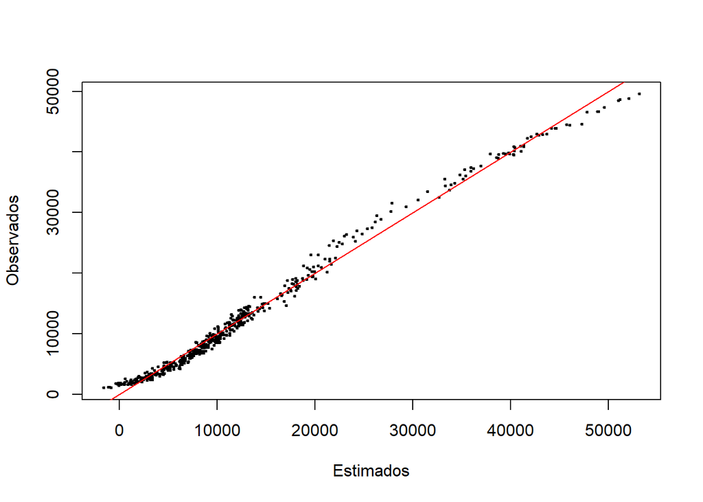

```r
plot(
  modelo_completo$fitted.values,
  obs$charges,
  xlab ="Estimados",
  ylab="Observados",
  pch=20,
  cex=0.5
)
abline(0,1,col="red")
```

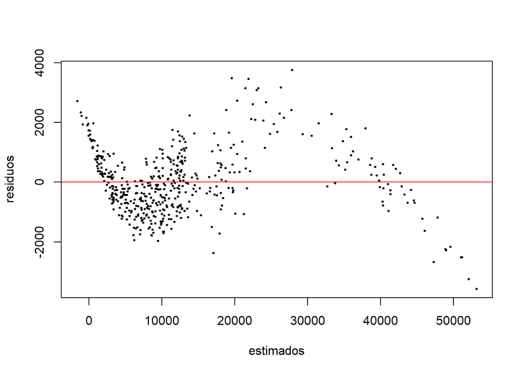

```r
plot(
  modelo_completo$fitted.values,
  modelo_completo$residuals,
  xlab ="estimados",
  ylab="residuos",
  pch=20,
  cex=0.5
)
abline(h=0,col="red")
```

#### Tests

**Prueba de homocedasticidad**

```r
ncvTest(modelo_completo)
```

```
data:
= 351173941, p-value < 2.2e-16
```

En base al p-valor menor a 0.05, se tiene suficiente evidencia de que la **varianza de los residuos no es constante**, es decir, no se cumple la homocedasticidad.

**Prueba de normalidad de los errores**

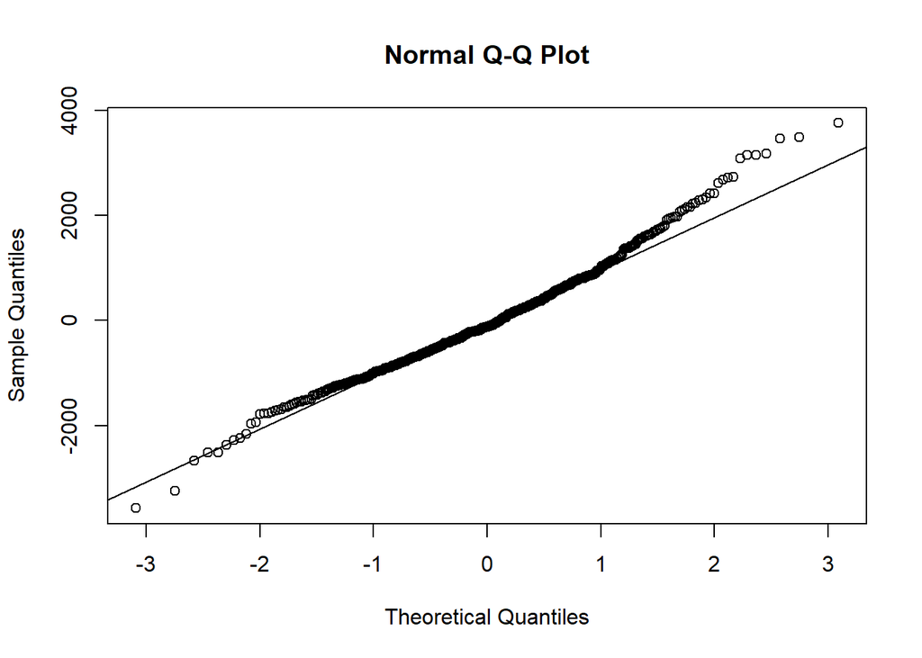

```r
qq_completo <- qqnorm(modelo_completo$residuals)
qqline(modelo_completo$residuals)
```

```r
shapiro.test(modelo_completo$residuals)
```

```
    Shapiro-Wilk normality test

data:  modelo_completo$residuals
W = 0.98331, p-value = 1.677e-05
```

En base al p-valor menor a 0.05, contamos con suficiente evidencia para afirmar que los **residuos no siguen una distribución normal**.

```r
shapiro.test(rstandard(modelo_completo))
```

```
    Shapiro-Wilk normality test

data:  rstandard(modelo_completo)
W = 0.98249, p-value = 1.01e-05
```

Al ejecutar el test para los residuos estandarizados, se llega a la misma conclusión respecto a la normalidad de los residuos.

Como se ha fallado en ambos tests, no estamos en condición formal de aplicar ANOVA. Sin embargo, inspeccionemos su resultado de todas maneras, según la tabla de análisis de la varianza.

```r
anova(modelo_completo)
```

```
Analysis of Variance Table

Response: charges
                                 Df     Sum Sq    Mean Sq  F value    Pr(>F)
sex                               1 5.6614e+08 5.6614e+08   474.88 < 2.2e-16
smoker                            1 3.9087e+10 3.9087e+10 32786.75 < 2.2e-16
age                               1 7.7570e+09 7.7570e+09  6506.60 < 2.2e-16
bmi                               1 1.6345e+09 1.6345e+09  1371.07 < 2.2e-16
Claim_Amount                      1 6.8192e+08 6.8192e+08   572.00 < 2.2e-16
past_consultations                1 1.3044e+09 1.3044e+09  1094.15 < 2.2e-16
num_of_steps                      1 6.3277e+09 6.3277e+09  5307.70 < 2.2e-16
Number_of_past_hospitalizations   1 6.6481e+08 6.6481e+08   557.65 < 2.2e-16
Anual_Salary                      1 6.1018e+09 6.1018e+09  5118.27 < 2.2e-16
Residuals                       490 5.8416e+08 1.1922e+06

sex                             ***
smoker                          ***
age                             ***
bmi                             ***
Claim_Amount                    ***
past_consultations              ***
num_of_steps                    ***
Number_of_past_hospitalizations ***
Anual_Salary                    ***
Residuals
---
Signif. codes:  0 '***' 0.001 '**' 0.01 '*' 0.05 '.' 0.1 ' ' 1
```

```r
extraer_estadistica_f(modelo_completo)
```

```
   value
5976.563
```

```r
obtener_p_valor_de_estadistica_f(modelo_completo)
```

```
value
    0
```

Como el p-valor es mucho menor que 0.05, concluimos que este modelo tiene sentido. En particular, existe alguna covariable que explica significativamente la varianza asociada a `charges`.

```r
extraer_info_t_student(modelo_completo)
```

```
                                    t value      Pr(>|t|) es_significativo
sexmale                          1.02617973  3.053132e-01            FALSE
smokeryes                        1.53299676  1.259220e-01            FALSE
age                             -5.09735180  4.927953e-07             TRUE
bmi                             -1.84969716  6.495914e-02            FALSE
Claim_Amount                     0.63850065  5.234461e-01            FALSE
past_consultations               0.09390782  9.252208e-01            FALSE
num_of_steps                    40.43404893 3.256649e-158             TRUE
Number_of_past_hospitalizations -5.24178980  2.368235e-07             TRUE
Anual_Salary                    71.54209305 1.626762e-261             TRUE
```

Por otro lado, según este otro test, solo se puede afirmar para las variables `age`, `num_of_steps`, `Number_of_past_hospitalizations` y `Anual_Salary` que tienen sentido en el modelo.

#### Puntos aberrantes

```r
modelo_completo.cd <- cooks.distance(modelo_completo)
modelo_completo.mcd <- mean(modelo_completo.cd)
```

**Puntos más lejos de 3 promedios**

```r
modelo_completo.cooked_1 <- which(modelo_completo.cd > 3*modelo_completo.mcd)
modelo_completo.cooked_1
```

```
  2  11  14  19  29  31  68  78  85 106 129 138 162 168 223 225 240 242 258 260
  2  11  14  19  29  31  68  78  85 106 129 138 162 168 223 225 240 242 258 260
267 292 299 316 329 331 347 362 365 373 385 396 412 449 453 455 486 496
267 292 299 316 329 331 347 362 365 373 385 396 412 449 453 455 486 496
```

Según aquel criterio, se tienen $38$ puntos aberrantes … una cantidad significativa.

**Puntos más lejos de cuatro veces los regresores**

```r
modelo_completo.cooked_2 <- which(modelo_completo.cd > (4 / dim(obs)))
modelo_completo.cooked_2
```

```
 11  19  29  31  85 129 223 225 263 267 299 329 331 347 365 373 385 449 453 455
 11  19  29  31  85 129 223 225 263 267 299 329 331 347 365 373 385 449 453 455
```

Según este otro criterio, se tienen $20$ puntos aberrantes, también una cantidad significativa.

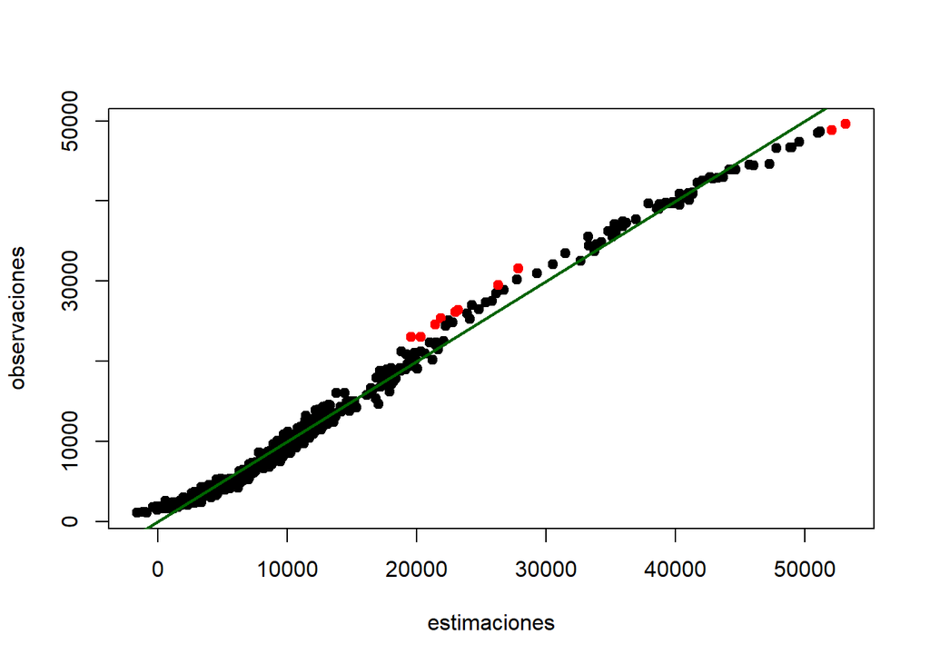

```r
modelo_completo.graficos_apalancamiento <- resaltar_n_puntos_con_mayor_apalancamiento(modelo_completo, 10)

modelo_completo.graficos_apalancamiento$est_vs_obs()
```

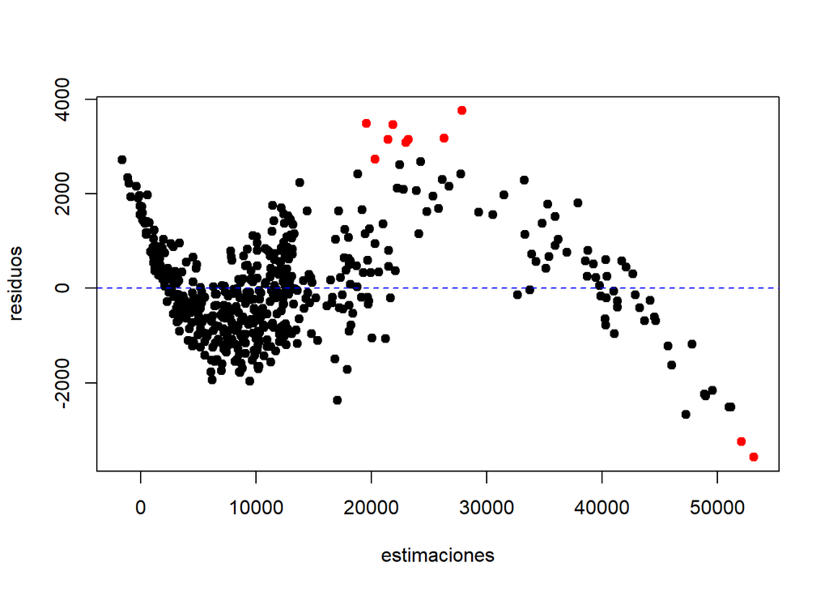

```r
modelo_completo.graficos_apalancamiento$est_vs_res()
```

### Modelo tras remover puntos aberrantes

```r
obs_sin_aber <- obs[-modelo_completo.cooked_1,]
obs_sin_aber
```

```
# A tibble: 462 x 10
   sex    smoker   age   bmi Claim_Amount past_consultations num_of_steps
   <chr>  <chr>  <dbl> <dbl>        <dbl>              <dbl>        <dbl>
 1 male   no        28  33.8       24108.                 18       983349
 2 male   yes       33  27.1       39953.                 27       996320
 3 female no        48  28.9       45756.                 24       912509
 4 male   no        63  31.4       34046.                 14       953355
 5 male   no        48  34.3       36944.                 18       926940
 6 female no        59  32.4       44302.                 18       940460
 7 male   no        38  34.7        8821.                 12       880463
 8 female no        63  31.8       26904.                 11       954102
 9 female no        22  24.3        5289.                  8       764144
10 female no        54  31.9       41178.                 24       919493
# i 452 more rows
# i 3 more variables: Number_of_past_hospitalizations <dbl>,
#   Anual_Salary <dbl>, charges <dbl>
```

```r
mod_com_2 <- lm(charges ~ ., obs_sin_aber)
sum.lm(mod_com_2)
```

```
Call:
lm(formula = charges ~ ., data = obs_sin_aber)

Residuals:
     Min       1Q   Median       3Q      Max
-2250.13  -580.13   -19.38   534.20  2564.82

Coefficients:
                                                2.5 %     97.5 % Std. Error
(Intercept)                     -4.026e+04 -4.196e+04 -3.857e+04  8.628e+02
sexmale                         -3.150e+01 -1.801e+02  1.172e+02  7.564e+01
smokeryes                        8.137e+02  3.846e+02  1.243e+03  2.183e+02
age                             -1.011e+01 -1.887e+01 -1.348e+00  4.457e+00
bmi                             -9.743e+00 -2.315e+01  3.664e+00  6.823e+00
Claim_Amount                    -1.612e-03 -6.884e-03  3.660e-03  2.683e-03
past_consultations               4.894e+00 -7.653e+00  1.744e+01  6.384e+00
num_of_steps                     5.521e-02  5.288e-02  5.754e-02  1.185e-03
Number_of_past_hospitalizations -1.900e+03 -2.209e+03 -1.591e+03  1.574e+02
Anual_Salary                     1.546e-05  1.510e-05  1.581e-05  1.817e-07
                                t value Pr(>|t|)
(Intercept)                     -46.665  < 2e-16 ***
sexmale                          -0.416 0.677332
smokeryes                         3.726 0.000219 ***
age                              -2.268 0.023820 *
bmi                              -1.428 0.153950
Claim_Amount                     -0.601 0.548244
past_consultations                0.767 0.443772
num_of_steps                     46.586  < 2e-16 ***
Number_of_past_hospitalizations -12.075  < 2e-16 ***
Anual_Salary                     85.090  < 2e-16 ***
---
Signif. codes:  0 '***' 0.001 '**' 0.01 '*' 0.05 '.' 0.1 ' ' 1

Residual standard error: 795.8 on 452 degrees of freedom
Multiple R-squared:  0.994, Adjusted R-squared:  0.9939
F-statistic:  8345 on 9 and 452 DF,  p-value: < 2.2e-16
```

Note que el porcentaje de varianza explicada aumentó de 99.1% a **99.4%**.

```r
calcular_rse(modelo_completo)
```

```
[1] 1091.864
```

```r
calcular_rse(mod_com_2)
```

```
[1] 795.7768
```

Asimismo, resaltamos que el **residuo promedio es menor** en el modelo tras remover puntos aberrantes.

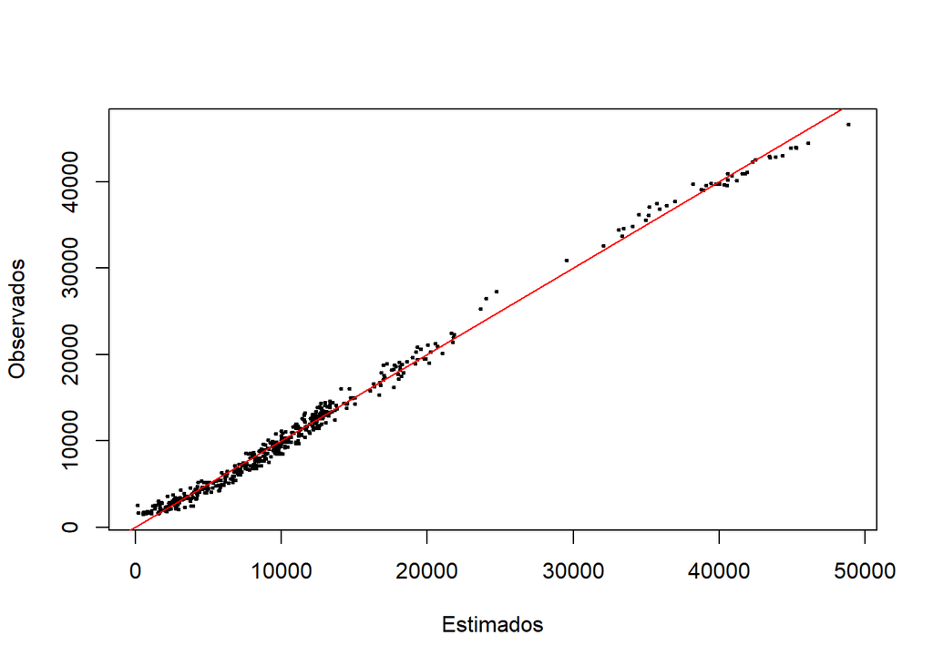

```r
plot(
  mod_com_2$fitted.values,
  obs_sin_aber$charges,
  xlab ="Estimados",
  ylab="Observados",
  pch=20,
  cex=0.5
)
abline(0,1,col="red")
```

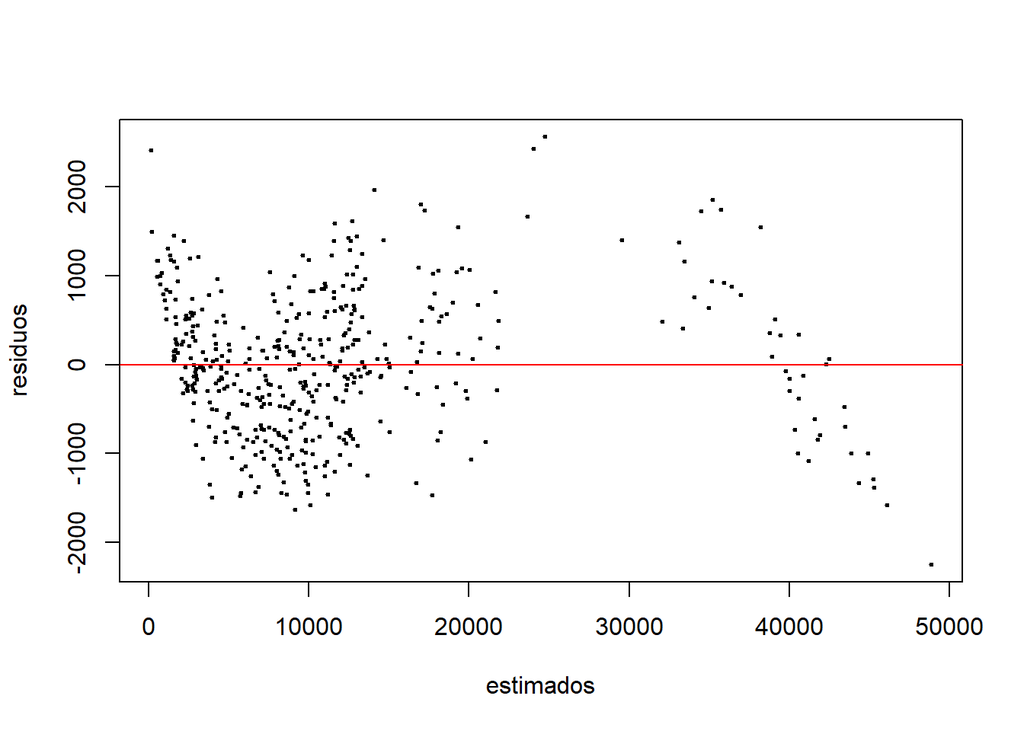

```r
plot(
  mod_com_2$fitted.values,
  mod_com_2$residuals,
  xlab ="estimados",
  ylab="residuos",
  pch=20,
  cex=0.5
)
abline(h=0,col="red")
```

```r
ncvTest(mod_com_2)
```

```
data:
= 167742048, p-value < 2.2e-16
```

El p-valor asociado al test de homocedasticidad prácticamente no ha cambiado.

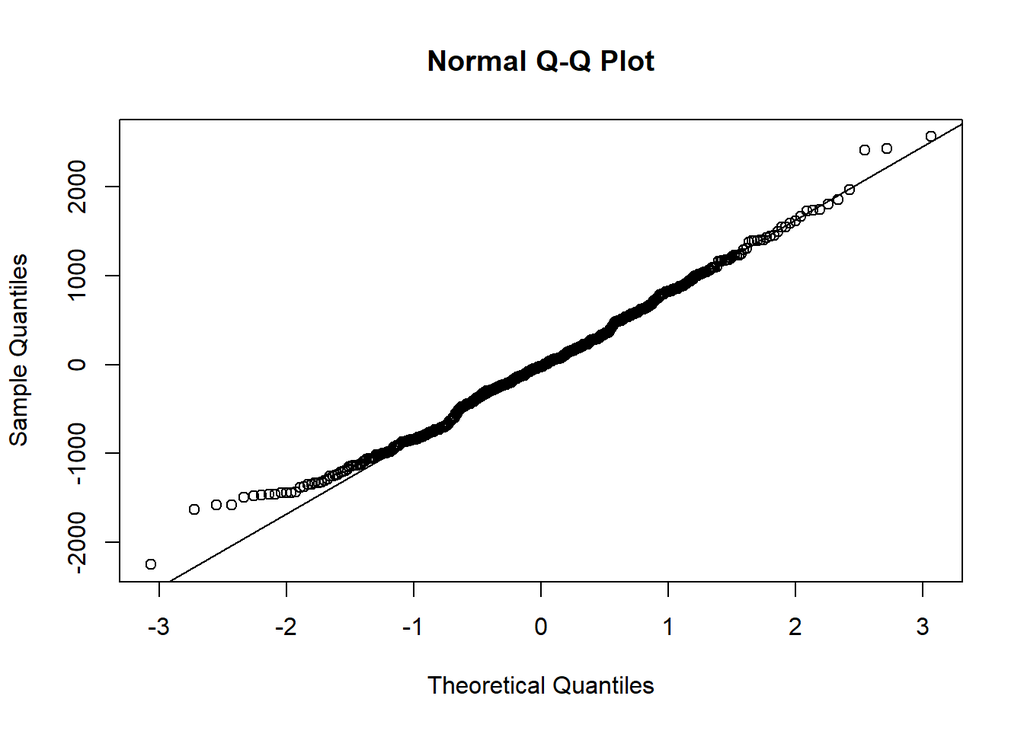

```r
qq_completo_2 <- qqnorm(mod_com_2$residuals)
qqline(mod_com_2$residuals)
```

```r
shapiro.test(mod_com_2$residuals)
```

```
    Shapiro-Wilk normality test

data:  mod_com_2$residuals
W = 0.99316, p-value = 0.03396
```

```r
shapiro.test(rstandard(mod_com_2))
```

```
    Shapiro-Wilk normality test

data:  rstandard(mod_com_2)
W = 0.9933, p-value = 0.0379
```

Por otro lado, el p-valor asociado al Test de Shapiro **aumentó significativamente**, de $1.01*10^{-5}$ a $0.0379$. Este último valor es cercano a 0.05, aunque aún menor, por lo cual se sigue evidenciando la **no normalidad** de los residuos tras haber removido aquellos puntos aberrantes.

En base a estas comparaciones, el modelo tras haber removido los puntos aberrantes resulta **mejor** que el modelo inicialmente construido.

### Selección reducida de covariables

Calculamos las correlaciones parciales para estas observaciones.

```r
covariables_numericas.2 <- c(
  "age",
  "bmi",
  "Claim_Amount",
  "past_consultations",
  "num_of_steps",
  "Number_of_past_hospitalizations",
  "Anual_Salary"
)

d.cor.2 <- cor(obs_sin_aber[, covariables_numericas.2])
d.inv.2 <- solve(d.cor.2)

d.corm.2 <- sqrt(1-1/diag(d.inv.2))
pd.2 <- length(d.corm.2)


d.part.2 <- d.inv.2
for (i in 1:pd.2) {
  for (j in 1:(i-1)) {
    d.part.2[i,j] <- -d.inv.2[i,j]/sqrt(d.inv.2[i,i]*d.inv.2[j,j])
  }
  d.part.2[i,i] <- d.corm.2[i]
  d.part.2[1:(i-1),i] <- d.part.2[i,1:(i-1)]
}
d.part.2
```

```
                                         age         bmi Claim_Amount
age                              0.665243871  0.16416635  -0.07721888
bmi                              0.164166348  0.28642055  -0.04976349
Claim_Amount                    -0.077218876 -0.04976349   0.39336416
past_consultations               0.013448272  0.03776371   0.02053137
num_of_steps                     0.583992833 -0.11066826   0.06308460
Number_of_past_hospitalizations  0.006854609  0.06287529   0.07840750
Anual_Salary                    -0.461124002  0.15756448   0.10218653
                                past_consultations num_of_steps
age                                     0.01344827    0.5839928
bmi                                     0.03776371   -0.1106683
Claim_Amount                            0.02053137    0.0630846
past_consultations                      0.54647920    0.1470056
num_of_steps                            0.14700565    0.8882175
Number_of_past_hospitalizations        -0.03927175    0.4190512
Anual_Salary                            0.21686281    0.4624652
                                Number_of_past_hospitalizations Anual_Salary
age                                                 0.006854609   -0.4611240
bmi                                                 0.062875288    0.1575645
Claim_Amount                                        0.078407497    0.1021865
past_consultations                                 -0.039271754    0.2168628
num_of_steps                                        0.419051171    0.4624652
Number_of_past_hospitalizations                     0.834430684    0.3550532
Anual_Salary                                        0.355053223    0.8544968
```

```r
vals_diag.2 <- diag(d.part.2)
max_col_indices.2 <- apply(d.part.2, 1, which.max)
idx_ordenados.2 <- order(vals_diag.2, decreasing = TRUE)
ordenados_vals_diag.2 <- vals_diag.2[idx_ordenados.2]

data.frame(correlacion_parcial = ordenados_vals_diag.2)
```

```
                                correlacion_parcial
num_of_steps                              0.8882175
Anual_Salary                              0.8544968
Number_of_past_hospitalizations           0.8344307
age                                       0.6652439
past_consultations                        0.5464792
Claim_Amount                              0.3933642
bmi                                       0.2864205
```

Note que aún existen covariables con correlación parcial elevada (`num_of_steps`, `Anual_Salary` y `Number_of_past_hospitalizations`), mayor que 0.8; pero ya no existe covariable con correlación parcial mayor a $0.9$.

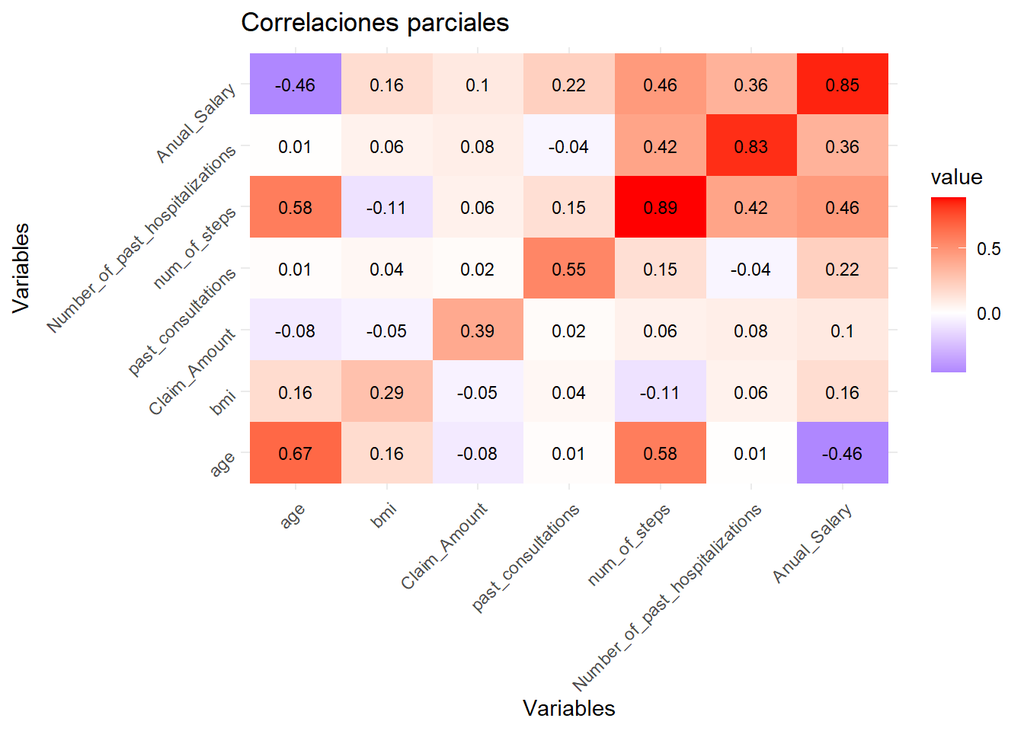

Sin embargo, los valores pequeños en valor absoluto para correlación parcial entre par de covariables implica que existe **poca multicolinealidad** entre las covariables.

```r
modelo_nulo <- lm(charges ~ 1, obs_sin_aber)
modelo_completo.2 <- lm(charges ~ ., obs_sin_aber)
```

```r
modelo_forward <- step(
  modelo_nulo,
  scope = list(
    lower = modelo_nulo,
    upper = modelo_completo.2
  ),
  direction = "forward",
  trace = 0
)

modelo_backward <- step(
  modelo_completo.2,
  scope = list(
    lower = modelo_nulo,
    upper = modelo_completo.2
  ),
  direction = "backward",
  trace = 0
)

modelo_both <- step(
  modelo_nulo,
  scope = list(
    lower = modelo_nulo,
    upper = modelo_completo.2
  ),
  direction = "both",
  trace = 0
)
```

```r
sum.lm(modelo_forward)
```

```
Call:
lm(formula = charges ~ Anual_Salary + num_of_steps + Number_of_past_hospitalizations +
    smoker + age + bmi, data = obs_sin_aber)

Residuals:
     Min       1Q   Median       3Q      Max
-2281.32  -580.54   -16.49   544.60  2573.51

Coefficients:
                                                2.5 %     97.5 % Std. Error
(Intercept)                     -4.036e+04 -4.204e+04 -3.868e+04  8.553e+02
Anual_Salary                     1.547e-05  1.512e-05  1.582e-05  1.774e-07
num_of_steps                     5.532e-02  5.301e-02  5.762e-02  1.173e-03
Number_of_past_hospitalizations -1.909e+03 -2.216e+03 -1.602e+03  1.561e+02
smokeryes                        8.004e+02  3.744e+02  1.226e+03  2.168e+02
age                             -1.006e+01 -1.880e+01 -1.334e+00  4.443e+00
bmi                             -9.569e+00 -2.292e+01  3.777e+00  6.792e+00
                                t value Pr(>|t|)
(Intercept)                     -47.182  < 2e-16 ***
Anual_Salary                     87.232  < 2e-16 ***
num_of_steps                     47.146  < 2e-16 ***
Number_of_past_hospitalizations -12.227  < 2e-16 ***
smokeryes                         3.692 0.000249 ***
age                              -2.265 0.023956 *
bmi                              -1.409 0.159512
---
Signif. codes:  0 '***' 0.001 '**' 0.01 '*' 0.05 '.' 0.1 ' ' 1

Residual standard error: 794 on 455 degrees of freedom
Multiple R-squared:  0.994, Adjusted R-squared:  0.9939
F-statistic: 1.257e+04 on 6 and 455 DF,  p-value: < 2.2e-16
```

```r
sum.lm(modelo_backward)
```

```
Call:
lm(formula = charges ~ smoker + age + bmi + num_of_steps + Number_of_past_hospitalizations +
    Anual_Salary, data = obs_sin_aber)

Residuals:
     Min       1Q   Median       3Q      Max
-2281.32  -580.54   -16.49   544.60  2573.51

Coefficients:
                                                2.5 %     97.5 % Std. Error
(Intercept)                     -4.036e+04 -4.204e+04 -3.868e+04  8.553e+02
smokeryes                        8.004e+02  3.744e+02  1.226e+03  2.168e+02
age                             -1.006e+01 -1.880e+01 -1.334e+00  4.443e+00
bmi                             -9.569e+00 -2.292e+01  3.777e+00  6.792e+00
num_of_steps                     5.532e-02  5.301e-02  5.762e-02  1.173e-03
Number_of_past_hospitalizations -1.909e+03 -2.216e+03 -1.602e+03  1.561e+02
Anual_Salary                     1.547e-05  1.512e-05  1.582e-05  1.774e-07
                                t value Pr(>|t|)
(Intercept)                     -47.182  < 2e-16 ***
smokeryes                         3.692 0.000249 ***
age                              -2.265 0.023956 *
bmi                              -1.409 0.159512
num_of_steps                     47.146  < 2e-16 ***
Number_of_past_hospitalizations -12.227  < 2e-16 ***
Anual_Salary                     87.232  < 2e-16 ***
---
Signif. codes:  0 '***' 0.001 '**' 0.01 '*' 0.05 '.' 0.1 ' ' 1

Residual standard error: 794 on 455 degrees of freedom
Multiple R-squared:  0.994, Adjusted R-squared:  0.9939
F-statistic: 1.257e+04 on 6 and 455 DF,  p-value: < 2.2e-16
```

```r
sum.lm(modelo_both)
```

```
Call:
lm(formula = charges ~ Anual_Salary + num_of_steps + Number_of_past_hospitalizations +
    smoker + age + bmi, data = obs_sin_aber)

Residuals:
     Min       1Q   Median       3Q      Max
-2281.32  -580.54   -16.49   544.60  2573.51

Coefficients:
                                                2.5 %     97.5 % Std. Error
(Intercept)                     -4.036e+04 -4.204e+04 -3.868e+04  8.553e+02
Anual_Salary                     1.547e-05  1.512e-05  1.582e-05  1.774e-07
num_of_steps                     5.532e-02  5.301e-02  5.762e-02  1.173e-03
Number_of_past_hospitalizations -1.909e+03 -2.216e+03 -1.602e+03  1.561e+02
smokeryes                        8.004e+02  3.744e+02  1.226e+03  2.168e+02
age                             -1.006e+01 -1.880e+01 -1.334e+00  4.443e+00
bmi                             -9.569e+00 -2.292e+01  3.777e+00  6.792e+00
                                t value Pr(>|t|)
(Intercept)                     -47.182  < 2e-16 ***
Anual_Salary                     87.232  < 2e-16 ***
num_of_steps                     47.146  < 2e-16 ***
Number_of_past_hospitalizations -12.227  < 2e-16 ***
smokeryes                         3.692 0.000249 ***
age                              -2.265 0.023956 *
bmi                              -1.409 0.159512
---
Signif. codes:  0 '***' 0.001 '**' 0.01 '*' 0.05 '.' 0.1 ' ' 1

Residual standard error: 794 on 455 degrees of freedom
Multiple R-squared:  0.994, Adjusted R-squared:  0.9939
F-statistic: 1.257e+04 on 6 and 455 DF,  p-value: < 2.2e-16
```

```r
calcular_rse(modelo_forward)
```

```
[1] 794.0415
```

```r
calcular_rse(modelo_backward)
```

```
[1] 794.0415
```

```r
calcular_rse(modelo_both)
```

```
[1] 794.0415
```

```r
calcular_rse(modelo_completo)
```

```
[1] 1091.864
```

```r
calcular_rse(mod_com_2)
```

```
[1] 795.7768
```

### Modelo final

Comparando las covariables finales de los tres últimos modelos creados, además de sus coeficientes respectivos, note que se trata de un único modelo.

Asimimo, aquel modelo presenta un $R^2$ elevado, similar al del previo mejor modelo, también con un valor aproximado a 99.4%.

No obstante, recalcamos que el nuevo modelo presenta un **residuo promedio menor** que el del mejor modelo que habíamos construído hasta ahora.

En ese sentido, el mejor modelo que planteamos es `modelo_both`. Este presenta como covariables a `age`, `Anual_Salary`, `bmi`, `smoker`, `num_of_steps` y `Number_of_past_hospitalizations`.

```r
modelo_both
```

```
Call:
lm(formula = charges ~ Anual_Salary + num_of_steps + Number_of_past_hospitalizations +
    smoker + age + bmi, data = obs_sin_aber)

Coefficients:
                    (Intercept)                     Anual_Salary
                     -4.036e+04                        1.547e-05
                   num_of_steps  Number_of_past_hospitalizations
                      5.532e-02                       -1.909e+03
                      smokeryes                              age
                      8.004e+02                       -1.006e+01
                            bmi
                     -9.569e+00
```

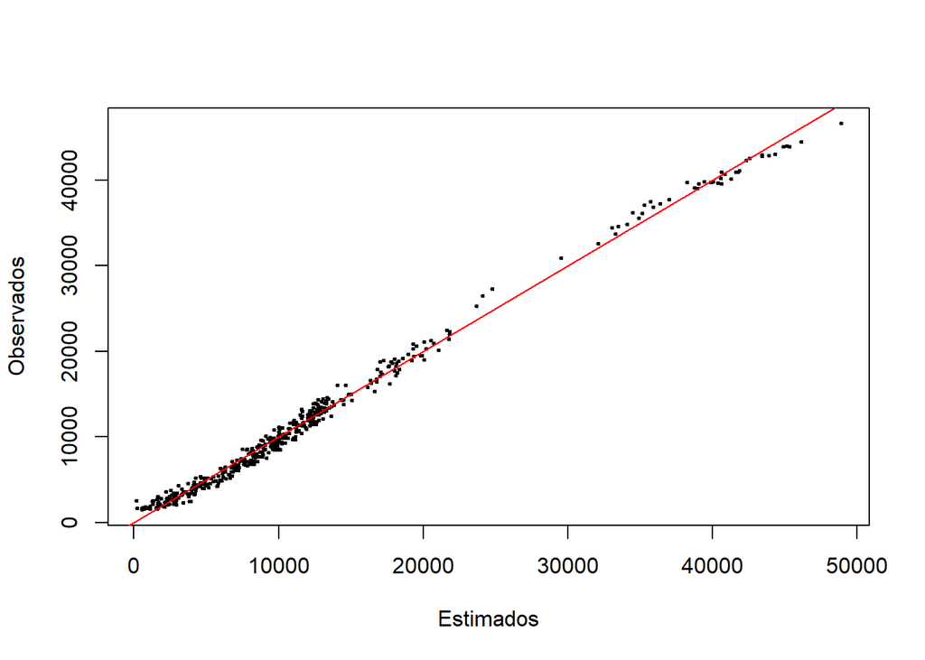

```r
plot(
  modelo_both$fitted.values,
  obs_sin_aber$charges,
  xlab ="Estimados",
  ylab="Observados",
  pch=20,
  cex=0.5
)
abline(0,1,col="red")
```

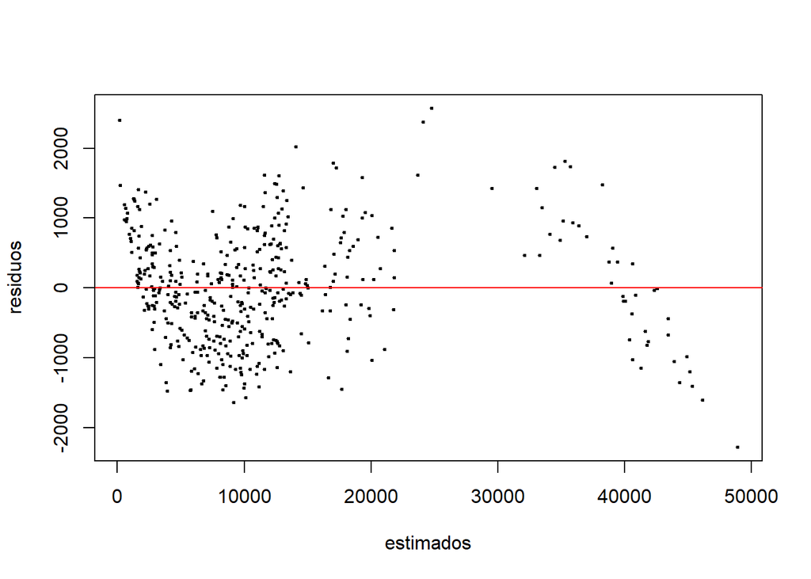

```r
plot(
  modelo_both$fitted.values,
  modelo_both$residuals,
  xlab ="estimados",
  ylab="residuos",
  pch=20,
  cex=0.5
)
abline(h=0,col="red")
```

**Prueba de homocedasticidad**

```r
ncvTest(modelo_both)
```

```
data:
= 167917219, p-value < 2.2e-16
```

**Prueba de normalidad de los errores**

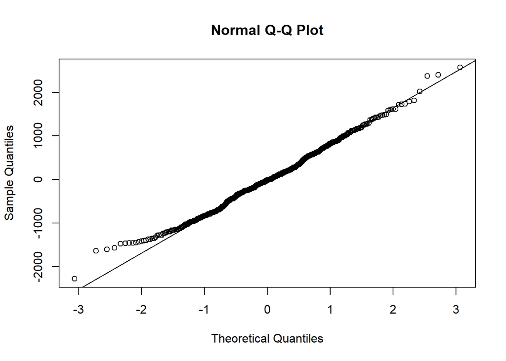

```r
qq_completo_3 <- qqnorm(modelo_both$residuals)
qqline(modelo_both$residuals)
```

```r
shapiro.test(modelo_both$residuals)
```

```
    Shapiro-Wilk normality test

data:  modelo_both$residuals
W = 0.99308, p-value = 0.03182
```

```r
shapiro.test(rstandard(modelo_both))
```

```
    Shapiro-Wilk normality test

data:  rstandard(modelo_both)
W = 0.99322, p-value = 0.03554
```

Para este modelo también se concluye que no se cumple la homocedasticidad y que los residuos no presentan una distribución normal.

```r
anova(modelo_both)
```

```
Analysis of Variance Table

Response: charges
                                 Df     Sum Sq    Mean Sq    F value    Pr(>F)
Anual_Salary                      1 4.3922e+10 4.3922e+10 69661.4333 < 2.2e-16
num_of_steps                      1 3.4856e+09 3.4856e+09  5528.3339 < 2.2e-16
Number_of_past_hospitalizations   1 1.1417e+08 1.1417e+08   181.0800 < 2.2e-16
smoker                            1 3.1743e+07 3.1743e+07    50.3452 4.973e-12
age                               1 3.1258e+06 3.1258e+06     4.9577   0.02646
bmi                               1 1.2518e+06 1.2518e+06     1.9853   0.15951
Residuals                       455 2.8688e+08 6.3050e+05

Anual_Salary                    ***
num_of_steps                    ***
Number_of_past_hospitalizations ***
smoker                          ***
age                             *
bmi
Residuals
---
Signif. codes:  0 '***' 0.001 '**' 0.01 '*' 0.05 '.' 0.1 ' ' 1
```

```r
extraer_estadistica_f(modelo_both)
```

```
   value
12571.36
```

```r
obtener_p_valor_de_estadistica_f(modelo_both)
```

```
value
    0
```

```r
extraer_info_t_student(modelo_both)
```

```
                                   t value      Pr(>|t|) es_significativo
Anual_Salary                     87.232374 3.440579e-286             TRUE
num_of_steps                     47.145582 3.122331e-177             TRUE
Number_of_past_hospitalizations -12.227038  6.354538e-30             TRUE
smokeryes                         3.692271  2.492338e-04             TRUE
age                              -2.265428  2.395574e-02             TRUE
bmi                              -1.409021  1.595120e-01            FALSE
```

A partir de estos dos últimos tests, se concluye que este modelo tiene sentido, pero que la covariable `bmi` no es significativa para ese modelo.

En base a que residuos de este modelo no satisfacen la hipótesis de homocedasticidad ni de distribución normal, no presentaremos los análisis de ANOVA tipo I, II ni III, por tratarse aquellas hipótesis de condiciones necesarias.

```r
sum.lm(modelo_completo)
```

```
Call:
lm(formula = charges ~ ., data = obs)

Residuals:
    Min      1Q  Median      3Q     Max
-3574.8  -728.0  -121.6   631.4  3762.3

Coefficients:
                                                2.5 %     97.5 % Std. Error
(Intercept)                     -4.223e+04 -4.430e+04 -4.016e+04  1.055e+03
sexmale                          1.018e+02 -9.310e+01  2.967e+02  9.919e+01
smokeryes                        3.807e+02 -1.072e+02  8.686e+02  2.483e+02
age                             -2.649e+01 -3.670e+01 -1.628e+01  5.196e+00
bmi                             -1.680e+01 -3.465e+01  1.046e+00  9.083e+00
Claim_Amount                     2.238e-03 -4.649e-03  9.125e-03  3.505e-03
past_consultations               7.868e-01 -1.567e+01  1.725e+01  8.378e+00
num_of_steps                     5.771e-02  5.491e-02  6.051e-02  1.427e-03
Number_of_past_hospitalizations -1.022e+03 -1.405e+03 -6.391e+02  1.950e+02
Anual_Salary                     1.451e-05  1.411e-05  1.490e-05  2.028e-07
                                t value Pr(>|t|)
(Intercept)                     -40.029  < 2e-16 ***
sexmale                           1.026    0.305
smokeryes                         1.533    0.126
age                              -5.097 4.93e-07 ***
bmi                              -1.850    0.065 .
Claim_Amount                      0.639    0.523
past_consultations                0.094    0.925
num_of_steps                     40.434  < 2e-16 ***
Number_of_past_hospitalizations  -5.242 2.37e-07 ***
Anual_Salary                     71.542  < 2e-16 ***
---
Signif. codes:  0 '***' 0.001 '**' 0.01 '*' 0.05 '.' 0.1 ' ' 1

Residual standard error: 1092 on 490 degrees of freedom
Multiple R-squared:  0.991, Adjusted R-squared:  0.9908
F-statistic:  5977 on 9 and 490 DF,  p-value: < 2.2e-16
```

```r
sum.lm(mod_com_2)
```

```
Call:
lm(formula = charges ~ ., data = obs_sin_aber)

Residuals:
     Min       1Q   Median       3Q      Max
-2250.13  -580.13   -19.38   534.20  2564.82

Coefficients:
                                                2.5 %     97.5 % Std. Error
(Intercept)                     -4.026e+04 -4.196e+04 -3.857e+04  8.628e+02
sexmale                         -3.150e+01 -1.801e+02  1.172e+02  7.564e+01
smokeryes                        8.137e+02  3.846e+02  1.243e+03  2.183e+02
age                             -1.011e+01 -1.887e+01 -1.348e+00  4.457e+00
bmi                             -9.743e+00 -2.315e+01  3.664e+00  6.823e+00
Claim_Amount                    -1.612e-03 -6.884e-03  3.660e-03  2.683e-03
past_consultations               4.894e+00 -7.653e+00  1.744e+01  6.384e+00
num_of_steps                     5.521e-02  5.288e-02  5.754e-02  1.185e-03
Number_of_past_hospitalizations -1.900e+03 -2.209e+03 -1.591e+03  1.574e+02
Anual_Salary                     1.546e-05  1.510e-05  1.581e-05  1.817e-07
                                t value Pr(>|t|)
(Intercept)                     -46.665  < 2e-16 ***
sexmale                          -0.416 0.677332
smokeryes                         3.726 0.000219 ***
age                              -2.268 0.023820 *
bmi                              -1.428 0.153950
Claim_Amount                     -0.601 0.548244
past_consultations                0.767 0.443772
num_of_steps                     46.586  < 2e-16 ***
Number_of_past_hospitalizations -12.075  < 2e-16 ***
Anual_Salary                     85.090  < 2e-16 ***
---
Signif. codes:  0 '***' 0.001 '**' 0.01 '*' 0.05 '.' 0.1 ' ' 1

Residual standard error: 795.8 on 452 degrees of freedom
Multiple R-squared:  0.994, Adjusted R-squared:  0.9939
F-statistic:  8345 on 9 and 452 DF,  p-value: < 2.2e-16
```

```r
sum.lm(modelo_both)
```

```
Call:
lm(formula = charges ~ Anual_Salary + num_of_steps + Number_of_past_hospitalizations +
    smoker + age + bmi, data = obs_sin_aber)

Residuals:
     Min       1Q   Median       3Q      Max
-2281.32  -580.54   -16.49   544.60  2573.51

Coefficients:
                                                2.5 %     97.5 % Std. Error
(Intercept)                     -4.036e+04 -4.204e+04 -3.868e+04  8.553e+02
Anual_Salary                     1.547e-05  1.512e-05  1.582e-05  1.774e-07
num_of_steps                     5.532e-02  5.301e-02  5.762e-02  1.173e-03
Number_of_past_hospitalizations -1.909e+03 -2.216e+03 -1.602e+03  1.561e+02
smokeryes                        8.004e+02  3.744e+02  1.226e+03  2.168e+02
age                             -1.006e+01 -1.880e+01 -1.334e+00  4.443e+00
bmi                             -9.569e+00 -2.292e+01  3.777e+00  6.792e+00
                                t value Pr(>|t|)
(Intercept)                     -47.182  < 2e-16 ***
Anual_Salary                     87.232  < 2e-16 ***
num_of_steps                     47.146  < 2e-16 ***
Number_of_past_hospitalizations -12.227  < 2e-16 ***
smokeryes                         3.692 0.000249 ***
age                              -2.265 0.023956 *
bmi                              -1.409 0.159512
---
Signif. codes:  0 '***' 0.001 '**' 0.01 '*' 0.05 '.' 0.1 ' ' 1

Residual standard error: 794 on 455 degrees of freedom
Multiple R-squared:  0.994, Adjusted R-squared:  0.9939
F-statistic: 1.257e+04 on 6 and 455 DF,  p-value: < 2.2e-16
```

```r
modelo_both
```

```
Call:
lm(formula = charges ~ Anual_Salary + num_of_steps + Number_of_past_hospitalizations +
    smoker + age + bmi, data = obs_sin_aber)

Coefficients:
                    (Intercept)                     Anual_Salary
                     -4.036e+04                        1.547e-05
                   num_of_steps  Number_of_past_hospitalizations
                      5.532e-02                       -1.909e+03
                      smokeryes                              age
                      8.004e+02                       -1.006e+01
                            bmi
                     -9.569e+00
```

```r
QuantPsyc::lm.beta(modelo_both)
```

```
                   Anual_Salary                    num_of_steps
                    0.670595357                     0.447768305
Number_of_past_hospitalizations                       smokeryes
                   -0.081873611                              NA
                            age                             bmi
                   -0.013754365                    -0.005523399
```

Entre lo positivo de este estudio, recalcamos que el modelo final presenta un alto valor de $R^2$. Sin embargo, el hecho que para todos los modelos que creamos se llegó a concluir no homocedasticidad y residuos con distribución no normal, parece sugerir que el modelo de regresión lineal posiblemente no sea el adecuado para estos datos.

En todo caso, resulta posible que un modelo lineal generalizado resulte más apropiado para el uso con estos datos, en particular debido a la no homocedasticidad encontrada.

Respecto al mejor modelo que presentamos, analicemos la relevancia de las covariables que consideró para su definición:

- `age`: Predictor muy relevante con la variable respuesta, pues, como se mencionó en una sección previa, sucede que paciente de mayor edad suelen requerir más cuidados médicos, su salud está en mayor riesgo, por lo que se espera que la aseguradora cubra más el costo de un tratamiento médico. En efecto, tal es el caso, pues el coeficiente asociado a `age` en el modelo resulta negativo. Así, a mayor edad del paciente, se espera que pague menos (pues la aseguradora cubre mayor costo) por un tratamiento médico.
- `Anual_Salary`: En el caso de pacientes con alto ingreso anual, se espera que sus tratamientos médicos sean también de alto costo. Esto implica que la aseguradora cubra una **menor proporción** del costo médico, pues la cobertura ya resulta alta en base al precio total del procedimiento. Esta relación se hace evidente en el hecho que el coeficiente asociado a `Annual_Salary` es positivo; es decir, a mayor salario anual, menos costo cubre la aseguradora.
- `bmi`: La relación entre esta covariable y la variable por predecir es muy similar la relación de la edad y la variable por predecir. Por ello, el análisis el análogo, y, simplemente recalcamos que el modelo resalta lo esperado (en base al coeficiente negativo asociado a `bmi`), pues, a mayor índice de masa corporal (`bmi`), la aseguradora cubre más del costo, por lo cual el paciente paga menos.
- `smoker`: En el modelo, esta covariable categórica ha sido convertida en 0 y 1; considerando el caso 1 cuando el paciente es fumador. En ese sentido, el coeficiente positivo asociado a esta covariable indice que, si el paciente es fumador, entonces su precio a pagar por tratamiento médico es también mayor, pues la aseguradora cubre **menos** del costo del procedimiento médico.
- `num_of_steps`: Recordemos que esta covariable la interpretamos como un indicador del estado de salud del paciente. Es decir, un mayor valor de `num_of_steps` representa un mejor estado de salud, de actividad física, del paciente. En ese sentido, es coherente que aquella covariable presente un coeficiente positivo según el modelo. Esto pues, mientras más saludable sea una persona, su gasto por procedimiento médico será mayor; es decir, la aseguradora cubrirá una **menor** cantidad del costo del procedimiento.
- `Number_of_past_hospitalizations`: Esta covariable es posiblemente la que más relación se espera tenga con la variable por predecir. El coeficiente negativo asociada a esta covariable es coherente con el hecho que, a mayor número de hospitalizaciones pasadas, se espera que el seguro cubra una mayor parte del costo del procedimiento médico, por lo cual el gasto del paciente es **menor** por procedimiento médico.

Como no existe una interpretación física, realista, al caso `bmi = 0`, no interpretaremos el intercepto asociado al modelo.

Este modelo se limita a las hipótesis del método MCO. Ahora analizaremos si un modelo del tipo **lineal generalizado** genera mejoras significativas.

Comencemos por una inspección de la homocedasticidad y autocorrelación de los errores del modelo MCO final.

```r
lmtest::bptest(modelo_both)
```

```
    studentized Breusch-Pagan test

data:  modelo_both
BP = 33.154, df = 6, p-value = 9.796e-06
```

```r
lmtest::dwtest(modelo_both)
```

```
    Durbin-Watson test

data:  modelo_both
DW = 2.1989, p-value = 0.9838
alternative hypothesis: true autocorrelation is greater than 0
```

Vía el test de Breusch-Pagan, con un p-valor de $9.796 \cdot 10^{-6}$, existe suficiente evidencia para afirmar el modelo planteado no presenta homocedasticidad. Por otro lado, vía el test de Durbin-Watson, con un p-valor de $0.9838$, no se cuenta con suficiente evidencia para rechazar que los errores del modelo son independientes entre sí.

En ese sentido, para los modelos de tipo lineal general por plantear no consideraremos el tipo **AR(1)**. De esa forma, plantearemos modelos del tipo con varianza ponderada, o varianza constante por categoría, o incluso una combinación de ambos modelos.

```r
lmtest::bptest(modelo_completo)
```

```
    studentized Breusch-Pagan test

data:  modelo_completo
BP = 74.086, df = 9, p-value = 2.394e-12
```

Asimismo, por medio del test de Breusch-Pagan, con un p-valor de $2.394 \cdot 10^{-12}$, existe suficiente evidencia para afirmar que el modelo completo (considerando todas las covariables) no presenta homocedasticidad. De esa forma, queda descartado el uso de técnicas de regularización como Lasso y Ridge, pues ambas suponen que los errores del modelo tienen varianza constante.

```r
obs_sin_aber$sex <- as.factor(obs_sin_aber$sex)
obs_sin_aber$smoker <- as.factor(obs_sin_aber$smoker)

AIC(modelo_both)
```

```
[1] 7489.719
```

```r
modelo_varianza_smoker <- gls(
  charges ~ Anual_Salary + num_of_steps + Number_of_past_hospitalizations + smoker + age + bmi,
  data = obs_sin_aber,
  weights = varIdent(form = ~1 | smoker)
)
summary(modelo_varianza_smoker)
```

```
Generalized least squares fit by REML
  Model: charges ~ Anual_Salary + num_of_steps + Number_of_past_hospitalizations +      smoker + age + bmi
  Data: obs_sin_aber
       AIC      BIC    logLik
  7488.658 7525.741 -3735.329

Variance function:
 Structure: Different standard deviations per stratum
 Formula: ~1 | smoker
 Parameter estimates:
      no      yes
1.000000 1.183794

Coefficients:
                                    Value Std.Error   t-value p-value
(Intercept)                     -40218.31  850.5036 -47.28764  0.0000
Anual_Salary                         0.00    0.0000  81.30548  0.0000
num_of_steps                         0.06    0.0012  47.24326  0.0000
Number_of_past_hospitalizations  -1976.60  153.1758 -12.90414  0.0000
smokeryes                          753.57  227.4076   3.31372  0.0010
age                                 -8.93    4.4639  -2.00119  0.0460
bmi                                -10.11    6.6520  -1.51942  0.1294

 Correlation:
                                (Intr) Anl_Sl nm_f_s Nmb___ smkrys age
Anual_Salary                     0.261
num_of_steps                    -0.963 -0.163
Number_of_past_hospitalizations  0.372 -0.347 -0.451
smokeryes                        0.412 -0.499 -0.501  0.167
age                              0.656  0.082 -0.738  0.113  0.557
bmi                             -0.173 -0.237 -0.049 -0.003  0.233  0.009

Standardized residuals:
        Min          Q1         Med          Q3         Max
-2.64965448 -0.72158780 -0.02942432  0.70512011  3.34042705

Residual standard error: 769.926
Degrees of freedom: 462 total; 455 residual
```

```r
modelo_varianza_sex <- gls(
  charges ~ Anual_Salary + num_of_steps + Number_of_past_hospitalizations + smoker + age + bmi,
  data = obs_sin_aber,
  weights = varIdent(form = ~1 | sex)
)
summary(modelo_varianza_sex)
```

```
Generalized least squares fit by REML
  Model: charges ~ Anual_Salary + num_of_steps + Number_of_past_hospitalizations +      smoker + age + bmi
  Data: obs_sin_aber
       AIC      BIC    logLik
  7491.814 7528.896 -3736.907

Variance function:
 Structure: Different standard deviations per stratum
 Formula: ~1 | sex
 Parameter estimates:
    male   female
1.000000 1.012337

Coefficients:
                                    Value Std.Error   t-value p-value
(Intercept)                     -40352.74  854.6374 -47.21621  0.0000
Anual_Salary                         0.00    0.0000  87.33646  0.0000
num_of_steps                         0.06    0.0012  47.17800  0.0000
Number_of_past_hospitalizations  -1908.23  156.0769 -12.22619  0.0000
smokeryes                          800.90  216.5790   3.69796  0.0002
age                                -10.17    4.4385  -2.29074  0.0224
bmi                                 -9.59    6.7913  -1.41266  0.1584

 Correlation:
                                (Intr) Anl_Sl nm_f_s Nmb___ smkrys age
Anual_Salary                     0.224
num_of_steps                    -0.961 -0.110
Number_of_past_hospitalizations  0.376 -0.411 -0.457
smokeryes                        0.471 -0.471 -0.571  0.199
age                              0.643  0.056 -0.730  0.120  0.602
bmi                             -0.164 -0.265 -0.064 -0.003  0.264  0.029

Standardized residuals:
        Min          Q1         Med          Q3         Max
-2.88788925 -0.72592646 -0.01978272  0.68124507  3.22302186

Residual standard error: 789.1097
Degrees of freedom: 462 total; 455 residual
```

Ahora, el mejor modelo (menor AIC) resulta aquel que emplea las covariables del previo mejor modelo, pero considerando varianza constante de `charges`, respecto a si el paciente fuma o no.

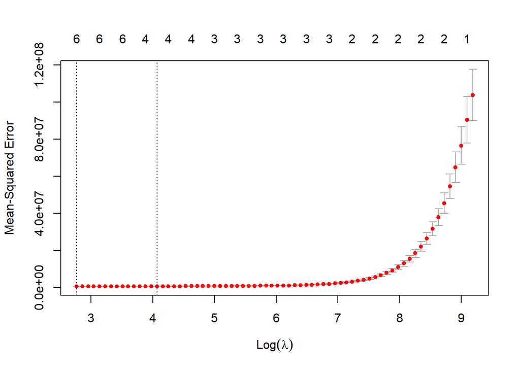

```r
X <- model.matrix(
  charges ~ age + Anual_Salary + bmi + smoker + num_of_steps + Number_of_past_hospitalizations,
  data = obs_sin_aber
)[,-1]
y <- obs_sin_aber$charges

set.seed(123)
cv_lasso <- cv.glmnet(X, y, alpha = 1, standardize = TRUE)
plot(cv_lasso)
```

```r
best_lambda <- cv_lasso$lambda.min
lambda_1se <- cv_lasso$lambda.1se
lasso_model <- glmnet(X, y, alpha = 1, lambda = best_lambda)

coef(lasso_model)
```

```
7 x 1 sparse Matrix of class "dgCMatrix"
                                           s0
(Intercept)                     -3.929155e+04
age                             -4.826183e+00
Anual_Salary                     1.532223e-05
bmi                             -5.534149e+00
smokeryes                        1.021077e+03
num_of_steps                     5.349238e-02
Number_of_past_hospitalizations -1.647969e+03
```

```r
coef_best <- coef(cv_lasso, s = best_lambda)
df_best <- sum(coef_best != 0) - 1

n <- length(y)
y_pred_best <- predict(cv_lasso, newx = X, s = best_lambda)
rss_best <- sum((y - y_pred_best)^2)
aic_best <- n * log(rss_best/n) + 2 * df_best
aic_best
```

```
[1] 6178.876
```